# rmarkdown notes

Steven Wong

May 22, 2016

# Resources

[RStudio R Markdown](http://rmarkdown.rstudio.com/)  
[R Markdown Cheat Sheet](https://www.rstudio.com/wp-content/uploads/2015/02/rmarkdown-cheatsheet.pdf)  
[R Markdown Reference Guide](https://www.rstudio.com/wp-content/uploads/2015/03/rmarkdown-reference.pdf) [Bookdown: Books with R Markdown](https://bookdown.org/yihui/bookdown/) [flexdashboard](http://rmarkdown.rstudio.com/flexdashboard/)

# Basics

A YAML is header is a set of key. Output can also be:

- pdf_document: for whatever reason, only works in `terminal`
- word_document
- beamer_document
- ioslides_document

To knitr the .Rmd file to the output, in R, execute:

```r
render("file.rmd")
```

To knitr the .Rmd file as `shiny` output, in R, execute:

```r
run("file.rmd")
```

# Basic Syntax

Plain text  
End a line with two spaces to start a new paragraph.

Or  
End a line with a `\`. This is useful in tables.

Put an empty line between two line to start a new paragraph, with a gap.

*italics* and *italics*  
**bold** and **bold**  
superscript<sup>2</sup>  
strikethrough  
link

# Header 1

## Header 2

# Header 1

## Header 2

### Header 3

#### Header 4

##### Header 5

###### Header 6

endash: –  
emdash: —  
ellipsis: …  
inline equation: $A = \pi*r^{2}$

> block quote

```
plain code blocks
```

Inline `code block`.

LaTeX Equations:
Inline: $equation$
Display equation:
$$equation$$

- unordered list
- item 2
  - sub-item 1
  - sub-item 2
1. ordered list
2. item 2
   - sub-item 1
   - sub-item 2

| Table Header | Second Header |
| --- | --- |
| Table Cell | Cell 2 |
| Cell 3 | Cell 4 |

horizontal rule (or slide break; 3 or more is good):

# Embedding R Codes

Default:

```r
paste("Hello, World!")
```

```
## [1] "Hello, World!"
```

Include code: 2 + 2 = 4

#### Chuck Options (inside {r})

To only show the codes:

```r
paste("Hello, World!")
```

To only show the evaluation:

```
## [1] "Hello, World!"
```

#### Example:

With ggplot2:

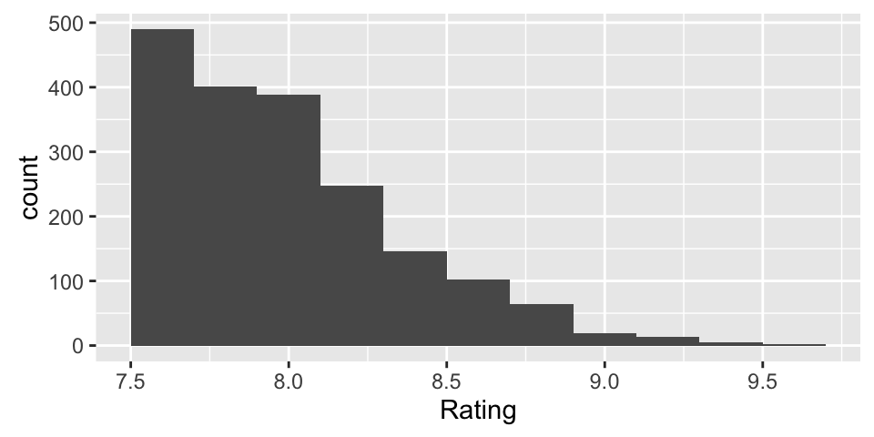

```r
imdb <- read_csv('~/Documents/Projects/IMDB/ratings_list_short_151120.csv')
ggplot(imdb, aes(x = Rating)) +
  geom_histogram(binwidth = 0.2)
```